# The impact of weather events in public health and economy based on the analysis of the NOAA storm database

Bruno

2023-07-21

# 1 Synopsis

In this work, we explore and analyze the U.S. National Oceanic and Atmospheric Administration’s (NOAA) storm database in order to determine the two weather events that resulted in the highest impact on the US population’s health and caused the largest economic consequences, respectively. Throughout our analysis, we concluded that **tornadoes** were the weather events that most impacted the number of fatalities and injuries; moreover, from the economic perspective, **floods** were responsible for the largest financial losses.

# 2 Introduction

It is known that extreme weather events can have a significant impact on public health and the economy. Such events may result in fatalities, injuries, and property and crop damage. Therefore, preventing such outcomes to the extent possible is in the public interest.

This project involves exploring the U.S. National Oceanic and Atmospheric Administration’s (NOAA) storm database. The data in the form of a comma-separated-value file was compressed via the bzip2 algorithm to reduce its size. You can download the file from the website:

- [Storm Data](https://d396qusza40orc.cloudfront.net/repdata%2Fdata%2FStormData.csv.bz2) [47Mb]

There is also some documentation of the database available. Here you will find how some of the variables were constructed/defined.

- National Weather Service [Storm Data Documentation](https://d396qusza40orc.cloudfront.net/repdata%2Fpeer2_doc%2Fpd01016005curr.pdf)
- National Climatic Data Center Storm Events [FAQ](https://d396qusza40orc.cloudfront.net/repdata%2Fpeer2_doc%2FNCDC%20Storm%20Events-FAQ%20Page.pdf)

The events in the database start in the year 1950 and end in November 2011. In the earlier years of the database, there were generally fewer events recorded, most likely due to a lack of good records. More recent years should be considered more complete.

# 3 Data Processing

In this work, the data was processed by using the following packages: **tidyverse** and **reshape2**.

```r
library(tidyverse)
library(reshape2)
```

First, we read the CSV file called *repdata_data_StormData.csv* located in the same folder as this R Markdown file.

```r
data <- read.csv("repdata_data_StormData.csv")
```

## 3.1 Inspecting data

Let us start by inspecting the data. First, we check the class and values of each variable present in the dataset.

```r
str(data)
```

```
## 'data.frame':    902297 obs. of  37 variables:
##  $ STATE__   : num  1 1 1 1 1 1 1 1 1 1 ...
##  $ BGN_DATE  : chr  "4/18/1950 0:00:00" "4/18/1950 0:00:00" "2/20/1951 0:00:00" "6/8/1951 0:00:00" ...
##  $ BGN_TIME  : chr  "0130" "0145" "1600" "0900" ...
##  $ TIME_ZONE : chr  "CST" "CST" "CST" "CST" ...
##  $ COUNTY    : num  97 3 57 89 43 77 9 123 125 57 ...
##  $ COUNTYNAME: chr  "MOBILE" "BALDWIN" "FAYETTE" "MADISON" ...
##  $ STATE     : chr  "AL" "AL" "AL" "AL" ...
##  $ EVTYPE    : chr  "TORNADO" "TORNADO" "TORNADO" "TORNADO" ...
##  $ BGN_RANGE : num  0 0 0 0 0 0 0 0 0 0 ...
##  $ BGN_AZI   : chr  "" "" "" "" ...
##  $ BGN_LOCATI: chr  "" "" "" "" ...
##  $ END_DATE  : chr  "" "" "" "" ...
##  $ END_TIME  : chr  "" "" "" "" ...
##  $ COUNTY_END: num  0 0 0 0 0 0 0 0 0 0 ...
```

[output cut: 23 more lines]

In the following, we summarize each variable in order to detect possible outliers or wrong entries of numerical values.

```r
summary(data)
```

```
##     STATE__       BGN_DATE           BGN_TIME          TIME_ZONE
##  Min.   : 1.0   Length:902297      Length:902297      Length:902297
##  1st Qu.:19.0   Class :character   Class :character   Class :character
##  Median :30.0   Mode  :character   Mode  :character   Mode  :character
##  Mean   :31.2
##  3rd Qu.:45.0
##  Max.   :95.0
##
##      COUNTY       COUNTYNAME           STATE              EVTYPE
##  Min.   :  0.0   Length:902297      Length:902297      Length:902297
##  1st Qu.: 31.0   Class :character   Class :character   Class :character
##  Median : 75.0   Mode  :character   Mode  :character   Mode  :character
##  Mean   :100.6
##  3rd Qu.:131.0
##  Max.   :873.0
##
##    BGN_RANGE          BGN_AZI           BGN_LOCATI          END_DATE
##  Min.   :   0.000   Length:902297      Length:902297      Length:902297
##  1st Qu.:   0.000   Class :character   Class :character   Class :character
##  Median :   0.000   Mode  :character   Mode  :character   Mode  :character
##  Mean   :   1.484
##  3rd Qu.:   1.000
##  Max.   :3749.000
##
##    END_TIME           COUNTY_END COUNTYENDN       END_RANGE
##  Length:902297      Min.   :0    Mode:logical   Min.   :  0.0000
##  Class :character   1st Qu.:0    NA's:902297    1st Qu.:  0.0000
##  Mode  :character   Median :0                   Median :  0.0000
##                     Mean   :0                   Mean   :  0.9862
##                     3rd Qu.:0                   3rd Qu.:  0.0000
##                     Max.   :0                   Max.   :925.0000
##
##    END_AZI           END_LOCATI            LENGTH              WIDTH
##  Length:902297      Length:902297      Min.   :   0.0000   Min.   :   0.000
##  Class :character   Class :character   1st Qu.:   0.0000   1st Qu.:   0.000
##  Mode  :character   Mode  :character   Median :   0.0000   Median :   0.000
##                                        Mean   :   0.2301   Mean   :   7.503
##                                        3rd Qu.:   0.0000   3rd Qu.:   0.000
##                                        Max.   :2315.0000   Max.   :4400.000
##
```

[output cut: 25 more lines]

```
##  Min.   :-14451   Min.   :   0   Min.   :-14455   Length:902297
##  1st Qu.:  7247   1st Qu.:   0   1st Qu.:     0   Class :character
##  Median :  8707   Median :   0   Median :     0   Mode  :character
##  Mean   :  6940   Mean   :1452   Mean   :  3509
##  3rd Qu.:  9605   3rd Qu.:3549   3rd Qu.:  8735
##  Max.   : 17124   Max.   :9706   Max.   :106220
##                   NA's   :40
##      REFNUM
##  Min.   :     1
##  1st Qu.:225575
##  Median :451149
##  Mean   :451149
##  3rd Qu.:676723
##  Max.   :902297
##
```

## 3.2 Trimming spaces

In order to inspect the variables whose values are strings, we introduce a list called unique_values containing the unique values of each variable sorted in ascending order.

```r
unique_values <-
        lapply(
                X = data,
                FUN = function(x)
                        sort(unique(x))
        )
```

Through the inspection of the unique values of EVTYPE, we note that there are some leading and trailing spaces that should be trimmed.

```r
head(unique_values$EVTYPE, n = 10)
```

```
##  [1] "   HIGH SURF ADVISORY" " COASTAL FLOOD"        " FLASH FLOOD"
##  [4] " LIGHTNING"            " TSTM WIND"            " TSTM WIND (G45)"
##  [7] " WATERSPOUT"           " WIND"                 "?"
## [10] "ABNORMAL WARMTH"
```

Therefore, we removed all leading and trailing spaces present in character variables.

```r
for (i in 1:ncol(data))
        if (is.character(data[, i]))
                data[, i] <- trimws(data[, i])
```

After formatting the data in a consistent format, we can confirm that there are no duplicates in our data.

```r
sum(duplicated(data))
```

```
## [1] 0
```

## 3.3 Handling exponent values

Since variables such as PROPDMGEXP and CROPDMGEXP can only take the values: H, h, K, k, M, m, B, b, +, -, ?, 0, 1, 2, 3, 4, 5, 6, 7, 8, and blank-character, we have to replace these codes by their corresponding numerical values. In this [link](https://rstudio-pubs-static.s3.amazonaws.com/58957_37b6723ee52b455990e149edde45e5b6.html), the reader can find more information on how to handle this issue. The following code address the aforementioned problem.

```r
EXP <- data.frame(
        Code = c("H","h","K","k","M","m","B","b","+","-","?","0","1","2","3","4","5","6","7","8",""),
        Number = c(10^2, 10^2, 10^3, 10^3, 10^6, 10^6, 10^9, 10^9, 1, 0, 0, 10, 10, 10, 10, 10, 10, 10, 10, 10, 0)
        )

data$PROPDMGEXP <- EXP$Number[match(data$PROPDMGEXP, EXP$Code)]
data$CROPDMGEXP <- EXP$Number[match(data$CROPDMGEXP, EXP$Code)]
```

## 3.4 Selecting data

Here, we select only the variables that will be useful in our analysis. We introduce the variables Property.Damage and Crop.Damage, which consist of PROPDMG and CROPDMG multiplied by their respective exponent values. The variables that are going to be used in our analysis are EVTYPE, FATALITIES, INJURIES, Property.Damage and Crop.Damage.

```r
data <- data %>%
        mutate(Property.Damage = PROPDMG * PROPDMGEXP,
               Crop.Damage = CROPDMG * CROPDMGEXP) %>%
        select(
                Event = EVTYPE,
                Fatalities = FATALITIES,
                Injuries = INJURIES,
                Property.Damage,
                Crop.Damage
        )
```

As the last step in our data cleaning process, we confirm that there are no missing values in our data.

```r
sum(!complete.cases(data))
```

```
## [1] 0
```

# 4 Analysis

In order to calculate the impact of each weather event on the number of fatalities and injuries, we group our data according to each event and calculate the total number of fatalities and injuries within each group. The following table shows the total number of fatalities and total injuries with respect to the top 10 events with the largest total impact (fatalities + injuries) on people’s health.

```r
summary1 <- data %>%
        group_by(Event) %>%
        summarize(Fatalities = sum(Fatalities),
                  Injuries = sum(Injuries)) %>%
        mutate(Total = Fatalities + Injuries) %>%
        arrange(desc(Total))

head(summary1, n = 10)
```

```
## # A tibble: 10 × 4
##    Event             Fatalities Injuries Total
##    <chr>                  <dbl>    <dbl> <dbl>
##  1 TORNADO                 5633    91346 96979
##  2 EXCESSIVE HEAT          1903     6525  8428
##  3 TSTM WIND                504     6957  7461
##  4 FLOOD                    470     6789  7259
##  5 LIGHTNING                816     5230  6046
##  6 HEAT                     937     2100  3037
##  7 FLASH FLOOD              978     1777  2755
##  8 ICE STORM                 89     1975  2064
##  9 THUNDERSTORM WIND        133     1488  1621
## 10 WINTER STORM             206     1321  1527
```

Analogously as before, we group our data according to each weather event and calculate the total cost damage related to properties and crops. In the following summary, we show the costs associated with the top 10 events with the highest (total) economic impact on the US economy.

```r
summary2 <- data %>%
        group_by(Event) %>%
        summarize(Property = sum(Property.Damage),
                  Crop = sum(Crop.Damage)) %>%
        mutate(Total = Property + Crop) %>%
        arrange(desc(Total))

head(summary2, n = 10)
```

```
## # A tibble: 10 × 4
##    Event                 Property        Crop        Total
##    <chr>                    <dbl>       <dbl>        <dbl>
##  1 FLOOD             144657709800  5661968450 150319678250
##  2 HURRICANE/TYPHOON  69305840000  2607872800  71913712800
##  3 TORNADO            56937162897   414954710  57352117607
##  4 STORM SURGE        43323536000        5000  43323541000
##  5 HAIL               15732269877  3025954650  18758224527
##  6 FLASH FLOOD        16140865011  1421317100  17562182111
##  7 DROUGHT             1046106000 13972566000  15018672000
##  8 HURRICANE          11868319010  2741910000  14610229010
##  9 RIVER FLOOD         5118945500  5029459000  10148404500
## 10 ICE STORM           3944928310  5022113500   8967041810
```

# 5 Results

In the following, we construct a bar plot containing the total number of fatalities and injuries for the top 10 weather events with the highest impact on US public health. According to this plot, the weather event that was most harmful to people’s health was the occurrence of **tornadoes**.

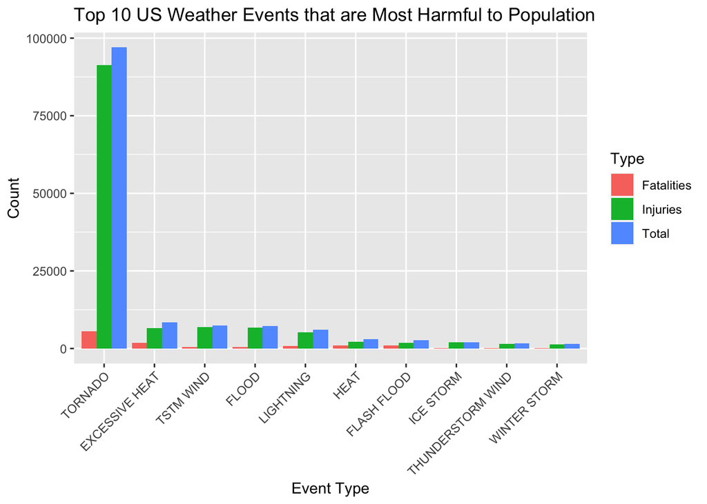

Figure 1. Top 10 weather events with the highest impact on the US public health

```r
impact1 <-
        melt(
                summary1[1:10,],
                id.vars = 1,
                variable.name = "Type",
                value.name = "Count"
        )

ggplot(impact1, aes(x = reorder(Event, -Count), y = Count)) +
        geom_bar(stat = "identity", aes(fill = Type), position = "dodge") +
        ylab("Count") +
        xlab("Event Type") +
        theme(axis.text.x = element_text(angle = 45, hjust = 1)) +
        ggtitle("Top 10 US Weather Events that are Most Harmful to Population")
```

We also explore the top 10 weather events with the highest economic impact on the US economy. In the following plot, we consider all these top 10 events and separately show the economic impact (in billion of Dollars) related to property damage and crop damage. By analyzing the plot below, we conclude that **floods** were responsible for the highest economic impact in the US.

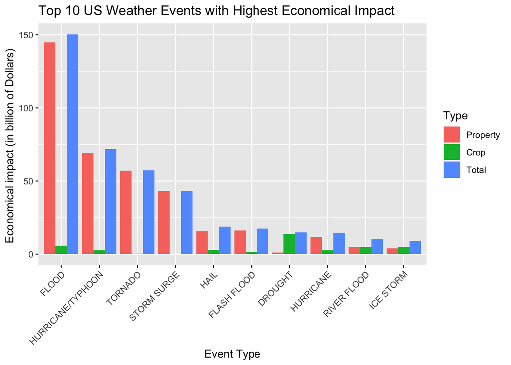

Figure 2. Top 10 weather events with the highest impact on the US economy

```r
impact2 <-
        melt(
                summary2[1:10,],
                id.vars = 1,
                variable.name = "Type",
                value.name = "Count"
        )

ggplot(impact2, aes(x = reorder(Event, -Count), y = Count / 10^9)) +
        geom_bar(stat = "identity", aes(fill = Type), position = "dodge") +
        ylab("Economical impact (in billion of Dollars) ") +
        xlab("Event Type") +
        theme(axis.text.x = element_text(angle = 45, hjust = 1)) +
        ggtitle("Top 10 US Weather Events with Highest Economical Impact")
```